# PCA Regression

Catalina Valencia

**Project:** US Crime Rate Modeling: Regression, Regularization, and Tree-Based Methods

**File:** 04_pca_regression.R

### Objectives:

- Apply Principal Component Analysis (PCA) to the US crime dataset.
- Construct a regression model using a reduced set of principal components.
- Express the fitted model in terms of the original predictor variables.

### Notes:

- PCA is performed on scaled predictors using prcomp(scale. = TRUE).
- No observations are removed from the dataset.
- Model quality is assessed using both in-sample fit and cross-validation.

Environment Setup

```r
rm(list = ls())
set.seed(1)
```

Load Data

```r
crimedata <- read.table(
  "../Data/uscrime.txt",
  header = TRUE,
  stringsAsFactors = FALSE
)
```

Separate response and predictors

```r
y <- crimedata$Crime
X <- crimedata[, names(crimedata) != "Crime"]
```

### Principal Component Analysis

- Reduce predictor dimensionality.
- Mitigate multicollinearity among variables.
- Preserve the majority of variability in the original data.

```r
pca_fit <- prcomp(X, scale. = TRUE)
summary(pca_fit)
```

```
## Importance of components:
##                           PC1    PC2    PC3     PC4     PC5     PC6     PC7
## Standard deviation     2.4534 1.6739 1.4160 1.07806 0.97893 0.74377 0.56729
## Proportion of Variance 0.4013 0.1868 0.1337 0.07748 0.06389 0.03688 0.02145
## Cumulative Proportion  0.4013 0.5880 0.7217 0.79920 0.86308 0.89996 0.92142
##                            PC8     PC9    PC10    PC11    PC12    PC13   PC14
## Standard deviation     0.55444 0.48493 0.44708 0.41915 0.35804 0.26333 0.2418
## Proportion of Variance 0.02049 0.01568 0.01333 0.01171 0.00855 0.00462 0.0039
## Cumulative Proportion  0.94191 0.95759 0.97091 0.98263 0.99117 0.99579 0.9997
##                           PC15
## Standard deviation     0.06793
## Proportion of Variance 0.00031
## Cumulative Proportion  1.00000
```

**Results:**

- Total number of predictors: 15
- Proportion of variance explained by leading components:

  PC1 = 0.4013 PC2 = 0.1868 PC3 = 0.1337 PC4 = 0.0775 PC5 = 0.0639
- Cumulative variance: PC1–PC3 = 0.7217 PC1–PC5 = 0.8631

The first k principal components are retained to balance variance preservation and model complexity.

**Selection of Number of Components**

- Retain enough components to explain a large fraction of total variance.
- Avoid overfitting given the small sample size (n = 47).

The first five principal components explain approximately 86.31% of the total variance in the predictor space.

```r
k <- 5

Z <- pca_fit$x[, 1:k]
```

### Regression on Principal Components

- Fit a linear regression using the retained principal components.
- Evaluate in-sample model fit.

```r
pcr_model <- lm(y ~ Z)
summary(pcr_model)
```

```
##
## Call:
## lm(formula = y ~ Z)
##
## Residuals:
##     Min      1Q  Median      3Q     Max
## -420.79 -185.01   12.21  146.24  447.86
##
## Coefficients:
##             Estimate Std. Error t value Pr(>|t|)
## (Intercept)   905.09      35.59  25.428  < 2e-16 ***
## ZPC1           65.22      14.67   4.447 6.51e-05 ***
## ZPC2          -70.08      21.49  -3.261  0.00224 **
## ZPC3           25.19      25.41   0.992  0.32725
## ZPC4           69.45      33.37   2.081  0.04374 *
## ZPC5         -229.04      36.75  -6.232 2.02e-07 ***
## ---
## Signif. codes:  0 '***' 0.001 '**' 0.01 '*' 0.05 '.' 0.1 ' ' 1
##
## Residual standard error: 244 on 41 degrees of freedom
## Multiple R-squared:  0.6452, Adjusted R-squared:  0.6019
## F-statistic: 14.91 on 5 and 41 DF,  p-value: 2.446e-08
```

**Results:**

- Number of principal components used: k = 5
- Residual standard error: 244.0000
- Multiple R-squared: 0.6452
- Adjusted R-squared: 0.6019

Compared to the full linear regression model:

- Full model R-squared: 0.8030
- Full model adjusted R-squared: 0.7080

The PCR model explains approximately 64.52% of the variability in the response using five orthogonal components derived from the original predictors. While the in-sample fit is lower than that of the full linear model, the reduction in dimensionality mitigates multicollinearity and reduces variance inflation.

This trade-off reflects the bias–variance balance inherent in principal component regression, favoring model stability and interpretability over maximal in-sample explanatory power.

**Expressing the PCR Model in Original Variables**

- Translate the PCR coefficients back into the original predictor space.
- Enable interpretation and prediction on new observations.

Extract principal component coefficients (excluding intercept)

```r
beta_pc <- coef(pcr_model)[-1]
```

Map coefficients back to standardized original variables

```r
beta_std <- pca_fit$rotation[, 1:k] %*% beta_pc
```

Unscale coefficients to original variable units

```r
beta_original <- beta_std / pca_fit$scale
```

Recover intercept in original scale

```r
intercept_original <- coef(pcr_model)[1] -
  sum(beta_original * pca_fit$center)

beta_original
```

```
##                 [,1]
## M       4.837374e+01
## So      7.901922e+01
## Ed      1.783120e+01
## Po1     3.948484e+01
## Po2     3.985892e+01
## LF      1.886946e+03
## M.F     3.669366e+01
## Pop     1.546583e+00
## NW      9.537384e+00
## U1      1.590115e+02
## U2      3.829933e+01
## Wealth  3.724014e-02
## Ineq    5.540321e+00
## Prob   -1.523521e+03
## Time    3.838779e+00
```

```r
intercept_original
```

```
## (Intercept)
##   -5933.837
```

**Results:**

- Intercept (original scale): -5933.8370
- Largest-magnitude coefficients (original variables): LF : 1886.9460 Prob : -1523.5210

Additional notable coefficients: U1 : 159.0115 So : 79.0192 M : 48.3737

These coefficients are obtained by back-transforming the principal component regression estimates to the original predictor space. As a result, they reflect combined effects of correlated predictors captured by the retained principal components, rather than isolated marginal effects as in standard multiple linear regression.

Coefficient magnitudes should therefore be interpreted cautiously and primarily in terms of relative influence, not direct causal impact.

### Cross-Validation for Model Quality

- Evaluate predictive performance under resampling.
- Compare PCR generalization to baseline regression models.

```r
library(DAAG)
```

```r
pcr_lm <- lm(
  Crime ~ .,
  data = data.frame(Crime = y, X)
)

cv_pcr <- cv.lm(crimedata, pcr_lm, m = 5)
```

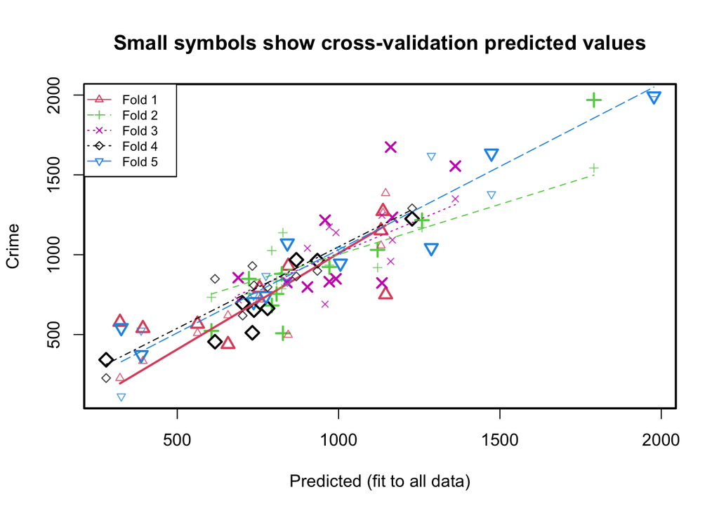

```
##
## fold 1
## Observations in test set: 9
##                     1        3       17       18        19        22         36
## Predicted   755.03222 322.2615 393.3633 843.8072 1145.7379  657.2092 1137.61711
## cvpred      719.48189 227.3811 334.2928 497.4904 1384.9349  620.1834 1261.61602
## Crime       791.00000 578.0000 539.0000 929.0000  750.0000  439.0000 1272.00000
## CV residual  71.51811 350.6189 204.7072 431.5096 -634.9349 -181.1834   10.38398
##                   38         40
## Predicted   562.6934 1131.45326
## cvpred      509.0826 1057.08701
## Crime       566.0000 1151.00000
## CV residual  56.9174   93.91299
##
## Sum of squares = 804290.7    Mean square = 89365.64    n = 9
##
## fold 2
## Observations in test set: 10
##                     4         6        12        25         28        32
## Predicted   1791.3619  792.9301 722.04080  605.8824 1258.48423 807.81667
## cvpred      1542.8663 1025.6864 752.84607  733.1797 1170.10415 836.60938
## Crime       1969.0000  682.0000 849.00000  523.0000 1216.00000 754.00000
## CV residual  426.1337 -343.6864  96.15393 -210.1797   45.89585 -82.60938
##                    34        41        44        46
## Predicted   971.45581 823.74192 1120.8227  827.3543
## cvpred      934.62797 786.74042  919.1066 1137.6778
## Crime       923.00000 880.00000 1030.0000  508.0000
## CV residual -11.62797  93.25958  110.8934 -629.6778
##
## Sum of squares = 779686.2    Mean square = 77968.62    n = 10
##
## fold 3
## Observations in test set: 10
##                     5         8        9        11        15        23
## Predicted   1166.6840 1361.7468 688.8682 1161.3291  903.3541  957.9918
## cvpred      1092.1924 1349.7715 717.0401  958.3058 1040.2775  690.2073
## Crime       1234.0000 1555.0000 856.0000 1674.0000  798.0000 1216.0000
## CV residual  141.8076  205.2285 138.9599  715.6942 -242.2775  525.7927
##                    37       39        43        47
## Predicted    971.1513 839.2864 1134.4172  991.7629
```

[output cut: 24 more lines]

[output not shown]

Compute cross-validated R-squared

```r
SStot <- sum((y - mean(y))^2)
SSres_cv <- attr(cv_pcr, "ms") * nrow(crimedata)

cv_r2_pcr <- 1 - SSres_cv / SStot
cv_r2_pcr
```

```
## [1] 0.419759
```

**Results:**

Baseline comparison:

- Full linear model CV R²: ≈ 0.4100
- Reduced linear model CV R²: ≈ 0.6400

The PCR model achieves cross-validated predictive performance comparable to the full linear regression model, but substantially lower than that of the reduced linear model.

While PCR effectively addresses multicollinearity through the use of orthogonal components, this dimensionality reduction does not translate into improved out-of-sample performance for this dataset. This suggests that the variance captured by the retained principal components is not fully aligned with the variance most relevant for predicting the response.

### Conclusion

Principal Component Regression was explored as a method to reduce dimensionality and address multicollinearity among predictors. While PCR improves coefficient stability by using orthogonal components, cross-validation indicates no meaningful improvement in predictive performance relative to the full linear regression model.

This suggests that the directions of greatest predictor variance are not strongly aligned with the variation most relevant for predicting crime rates. Given the limited sample size and the importance of interpretability, PCR is best viewed here as a robustness check rather than a primary modeling approach.